# API Token Guide (42 Intra)

This procedure is for local deployment (no VPS tunnel required).

## 1. Create your 42 OAuth application

Create a new application in 42 Intra:

[figure not shown]

Creation application

Set any values you want for name/description/website, but the redirect URI must match exactly:

`http://localhost:8580/callback`

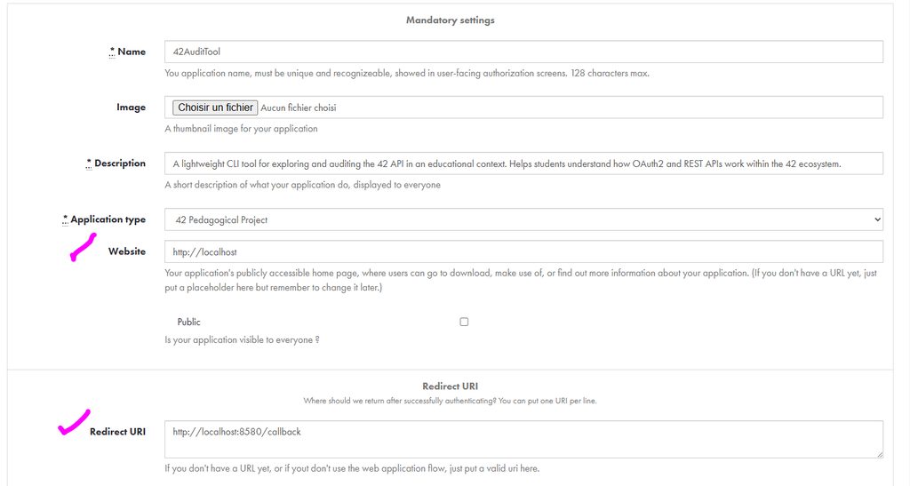

Application form

After submit, you should see the new app and its credentials:

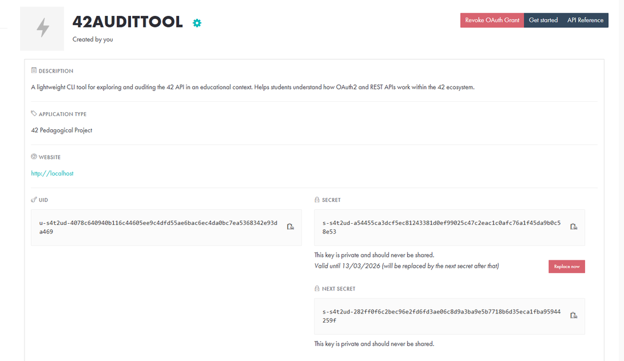

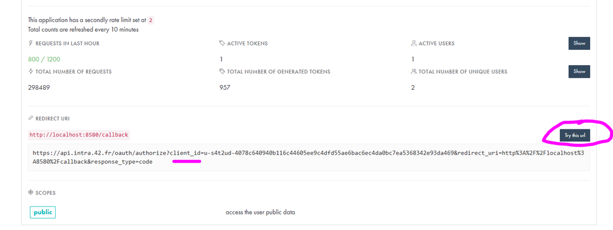

## 2. Get authorization code

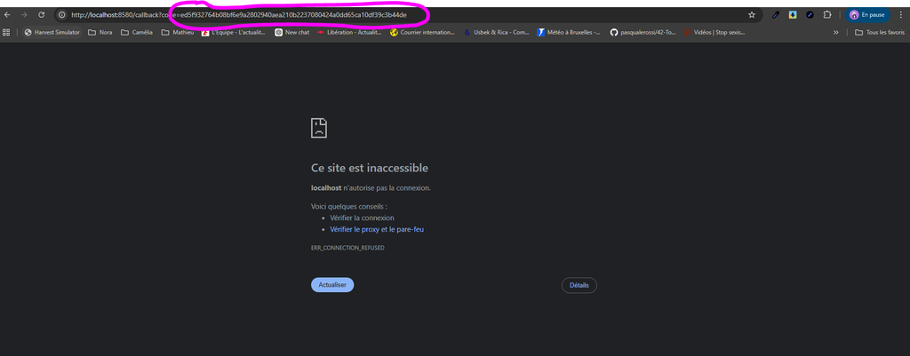

Use "Try this URL" to generate an authorization flow:

```
https://api.intra.42.fr/oauth/authorize?client_id=YOUR_CLIENT_ID&redirect_uri=http://localhost:8580/callback&response_type=code&scope=public
```

Approve access, then copy the returned:

```
code=...
```

## 3. Prepare configuration files

In `/srv/42_Network/.env` (API/OAuth only):

```
API_ROOT="https://api.intra.42.fr"
CLIENT_ID="your_client_id"
CLIENT_SECRET="your_client_secret"
NEXT_SECRET="your_next_secret"
REDIRECT_URI="http://localhost:8580/callback"
SCOPE="public"
ACCESS_TOKEN=""
REFRESH_TOKEN=""
```

In `/srv/42_Network/transcendance.config` (deployment config):

```
DB_HOST=localhost
DB_PORT=3306
DB_NAME=api42
DB_USER=api42
DB_PASSWORD=api42
WEB_PORT=8050
CAMPUS_ID=21
```

## 4. Exchange code for tokens

Run token commands from the repo using `./.cache/bin/token-manager-agent` (no `runtime/cache` path).

Use the authorization code obtained in section 2.

```bash
cd /srv/42_Network/repo
./.cache/bin/token-manager-agent exchange "<AUTHORIZATION_CODE>"
```

Verify saved tokens:

```bash
./.cache/bin/token-manager-agent token-info
```

## 5. Token manager commands

Run all commands from `/srv/42_Network/repo`.

```bash
./.cache/bin/token-manager-agent exchange "<AUTHORIZATION_CODE>"
```

- Exchange OAuth authorization code for `access_token` + `refresh_token`, then save state.

```bash
./.cache/bin/token-manager-agent refresh
```

- Refresh access token using the saved refresh token.

```bash
./.cache/bin/token-manager-agent ensure-fresh
```

- Refresh proactively if token expires in less than 1 hour.

```bash
./.cache/bin/token-manager-agent token-info
```

- Show locally saved token values and API `/oauth/token/info`.

```bash
./.cache/bin/token-manager-agent call /v2/me
```

- Call one endpoint with current token (auto-refresh on 401).

```bash
./.cache/bin/token-manager-agent call-export /v2/me me.json
```

- Call one endpoint and save pretty JSON to a file.

## 6. Deploy

```bash
cd /srv/42_Network/repo
make deploy
```